# Melanoma cell lines: Differential Gene Expression

Kostas Ntagiantas

June 25, 2018

# Introduction

To overcome the problem of randomness from taking a subgroup of melanoma samples to test vs healthy cells, the procedure is replicated 1000 times, with different samples every time. In each replication, the genes with p-value smaller than 0.05 and |logFC|>1 are saved. At the end of the simulation, the genes are ranked based on the number of the replications in which they are considered differential.

# Melanoma VS. Healthy

First, the only contrast used is Melanoma-Healthy. The sampling for the melanoma cell lines is first done globally, and then respectively to the clusters that are created from PCA. In the latter approach, the genes found are significantly different from cluster to cluster, and could be used to differentiate between them.

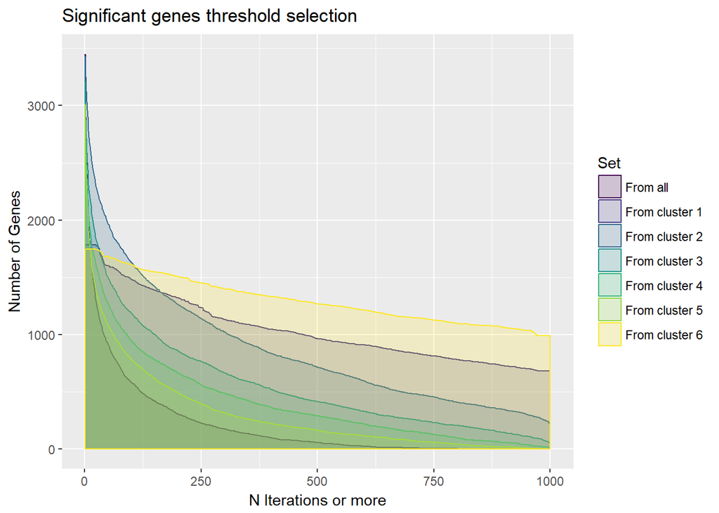

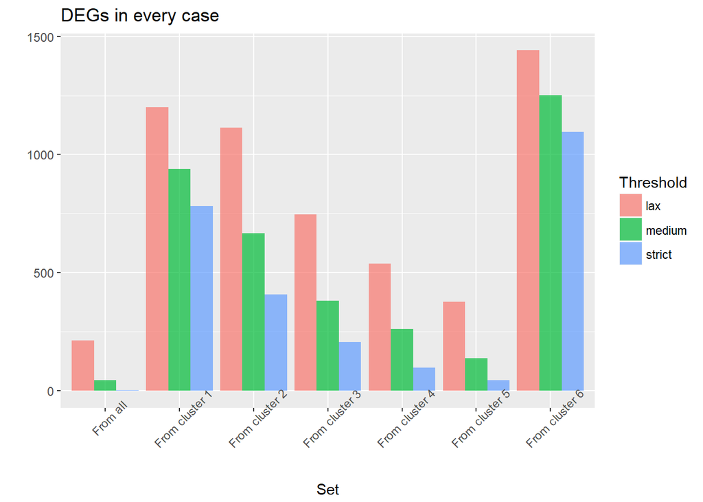

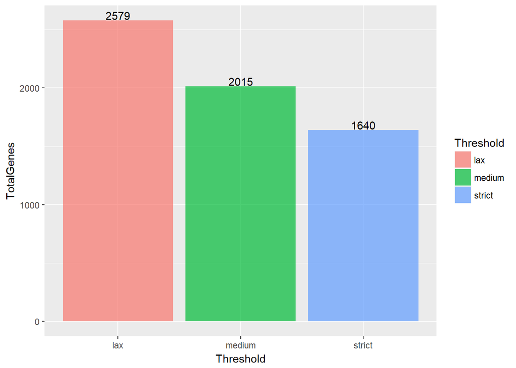

After selecting the three sets of differentially expressed genes according to the threshold, the goal is to use genes as predictors about the state of the cell. A good predictive model uses these genes to classify a cell between a healthy melanocyte and a cancerous melanoma cells. Therefore, the best predictors are genes that have been found as differentially expressed in all clusters. There are seven simulations, six of them are sampling cells from the six cancer clusters, and one that is sampling from all cancer clusters. PCA has shown great diversity of cancer cells. It is imperative that three different cases are studied:

1.**Case 1**:DEGs present in all seven simulations. 2.**Case 2**:DEGs present in the six simulations of the six clusters respectively 3.**Case 3**:DEGs present in the last simulation where sampling is across all melanoma samples.

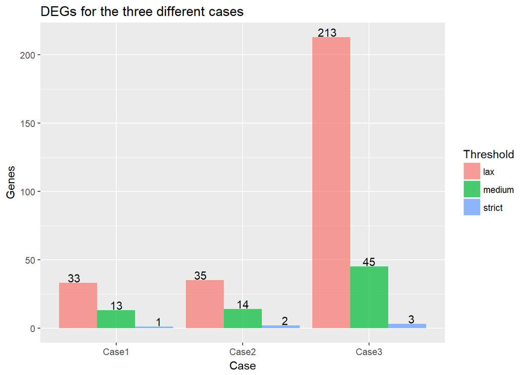

**Venn diagrams for the three different cases and each threshold**

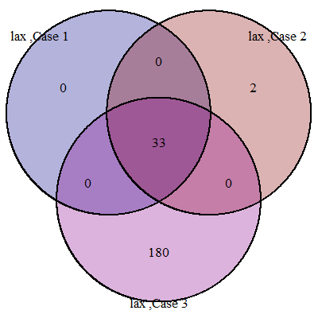

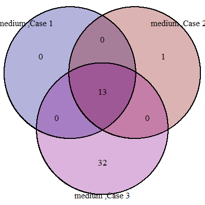

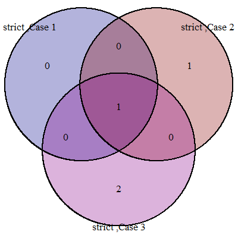

# Contrasting between different mutations

Now that the case of melanoma samples versus human melanocytes is done, the genes that define the various mutations have to be found. For this two cases are considered:

1. BRAF (+NRAS + PTEN) VS wild type VS Healthy
2. BRAF VS NRAS VS PTEN

The samples are distributed as follows across the different categories:

| BRAF | NRAS | PTEN | wt | Control |
| --- | --- | --- | --- | --- |
| 84 | 22 | 16 | 22 | 6 |

It has to be noted that all cell lines that bear the PTEN mutation and one that bears the NRAS mutation also have the BRAF mutation in the particular dataset that is being studied.

Now that we wee need to find differences between mutations, we see that the samples are not so imbalanced as in the case of melanoma vs healthy. Therefore there is no need to have the iterative process in order to filter the truly differentially expressed genes.

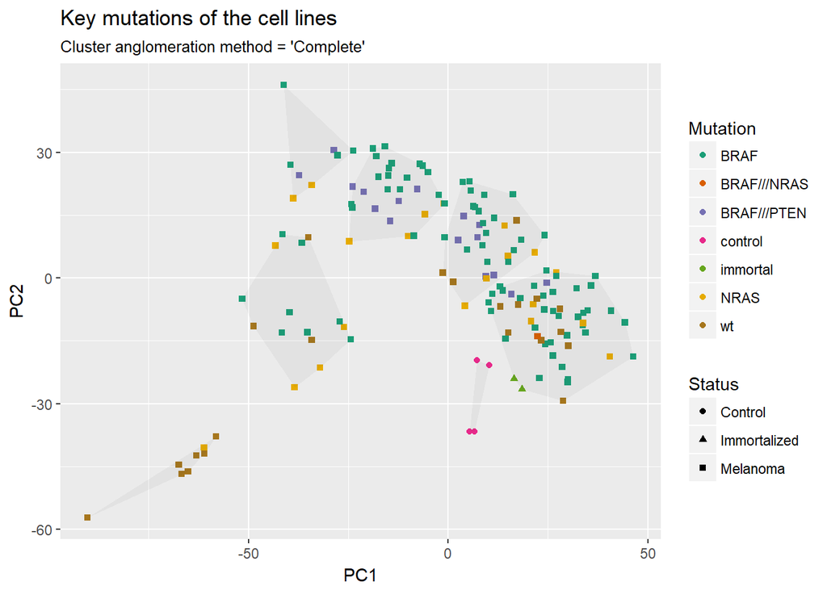

It is obvious that the cell lines that bear the three melanoma mutations have a lot in common, as the number of genes that are differentially expressed, even after an analysis of 1000 simulations is greatly smaller than the genes in when contrasting the mutant cells to healthy melanocytes but also to wild type melanoma cells.

To find the genes that define the two cases of contrasts mentioned above it is imperative to find the difference between the various sets. That is, find the genes that are differentially expressed exclusively in every set.

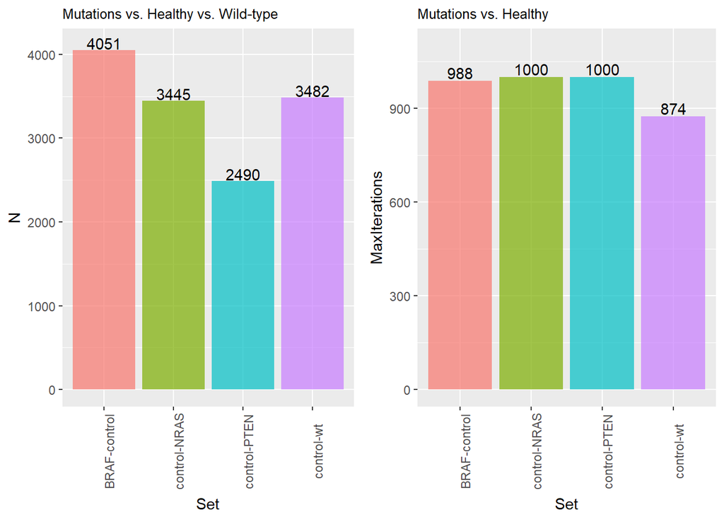

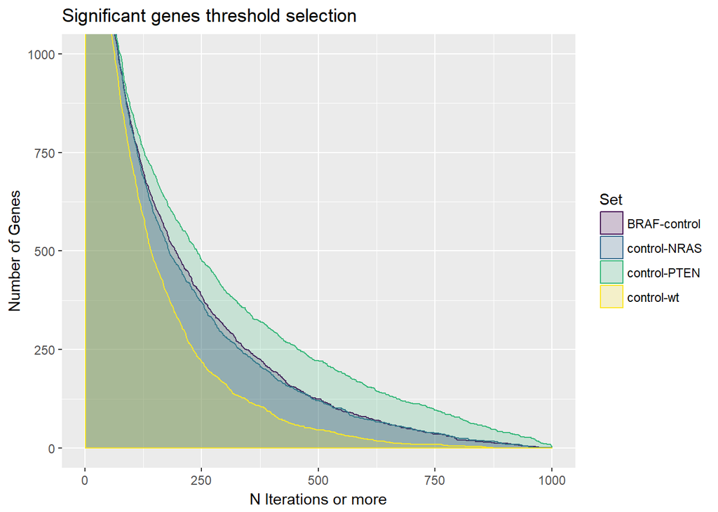

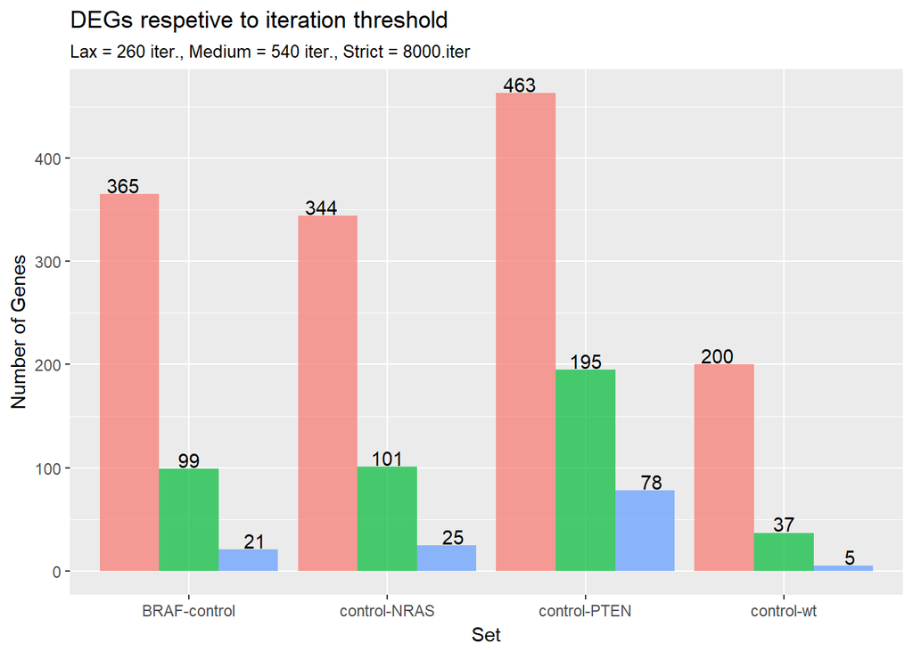

If we compare the threshold selection figures for the melanoma-healthy contrasts when sampling by cluster and when sampling by mutation, we see that the analysis is much more robust when sampling from the same cluster instead of sampling from the same mutation. This is explained by the high in-set variance in each mutation group.

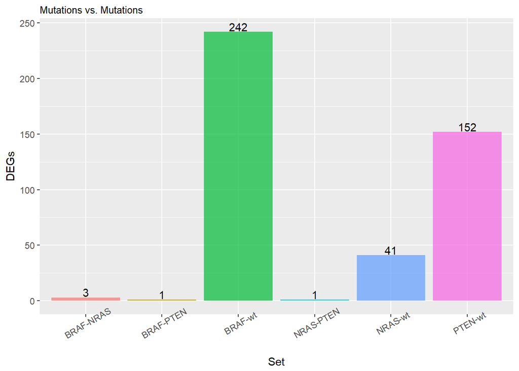

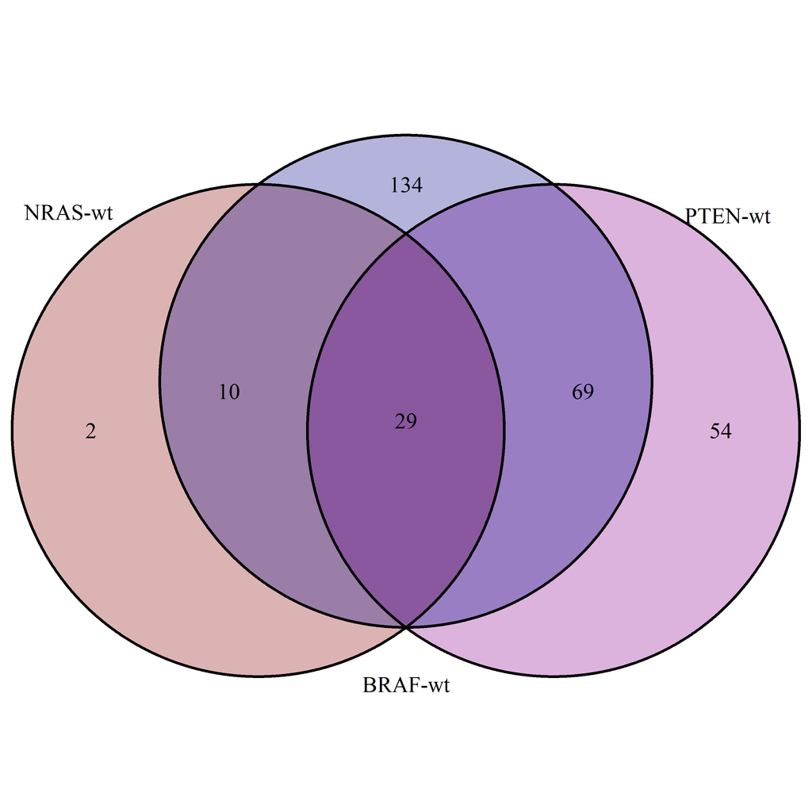

Mutations vs. wt